# PetDB data analysis

Elliot Carter

18/10/2021

## Geographic analysis of PetDB records

The following is a working document written in R markdown. The objective in the code outlined by this document is to first determine the country of affiliation of published works recorded in the PetDB database of geochemical data.

The dois of PetDB records were retrieved by data mining and are stored in the file “specimen_locations_new.csv”.

These dois are then used (in Sections 1 and 2) to manually search the Web of Science database to retrievev author address data for ~1500 publications.

The bulk of the code which follows is concerned with automatically detecting countries in those addresses and cleaning up various errors and difficulties with the data.

Finally, the datasets are combined to give a record of the country from which the samples, authors and 1st author derive for ~1500 geochemical publications.

In the final sections some preliminary data analysis is made looking at the patterns of: which countries tend to conduct research domestically and abroad; which are most and least subject to other countries’ research; and which are most and least likely to include local researchers as co-authors when researching samples from abroad.

## 1 Make list of DOIs to search Web of Science

```r
# read in scraped PetDB data
# scaping done using Jupiter notebook
# https://github.com/GeoCoLab/notebooks/tree/main/specimen-locations
refs<-read.csv("./data/PetDB_specimen_locations.csv", encoding = "UTF-8")

# filter out records with no doi or no specimen location (mostly deep ocean samples)
dois<-refs%>%
  filter(specimen_locations!="", doi!="")%>%
  pull(doi)

# collapse vector of dois into single string separated by " OR "
string<-paste(dois, collapse = " OR ")

# output search string to text file for easier copy/pasting
# if it doesn't already exist (because slow!)
if(!file.exists("./data/search_string.txt")){
  write.table(string, "./data/search_string.txt", row.names = F)
}
```

## 2. Manually search Web of Science by DOI

Search done at https://www.webofscience.com/wos/woscc/summary/1bd1f26a-e825-446a-ba7f-4cc2e8126141-0bad9599/relevance/1

From 2030 DOIs found 1493 records

Results in “WoS_records.csv”

## 3. Get list of countries

Various simplifications and synomyms have been added to give a unified preferred name to all affiliation and sample locations

This allows us to match these later in the analysis

```r
# get list of countries
countries<-read.csv("./data/countries.csv")
head(countries)%>%as_tibble()
```

```
## # A tibble: 6 x 7
##   Name           Code  Synonym Semi.autonomous.~ Authority Preferred.Name Region
##   <chr>          <chr> <chr>   <chr>             <chr>     <chr>          <chr>
## 1 Afghanistan    AF    ""      ""                ""        Afghanistan    Asia
## 2 Åland Islands  AX    ""      "Y"               "Finland" Åland Islands  Europe
## 3 Albania        AL    ""      ""                ""        Albania        Europe
## 4 Algeria        DZ    ""      ""                ""        Algeria        Africa
## 5 American Samoa AS    ""      "Y"               "United ~ American Samoa Ocean~
## 6 Andorra        AD    ""      ""                ""        Andorra        Europe
```

```r
# make capitalised vector of countries
country<-toupper(countries$Name)
```

## 4. Load Web of Science data and tidy up

All records returned by manual doi search at Web of Science loaded in a dataframe.

Each step is repeated for all authors (the Addresses field =>> add) and the corresponding author (the Reprint.Addresses field =>> corradd). The latter is taken to be the first author hereafter.

```r
# Read in Web of Science data
wos<-read.csv("./data/WoS_records.csv")
# str(wos) # check structure if necessary
```

Key fields from Web of Science (WoS) data

```
## # A tibble: 6 x 5
##   Addresses      Reprint.Addresses     DOI     Publication.Year Funding.Orgs
##   <chr>          <chr>                 <chr>              <int> <chr>
## 1 [Gaschnig, Ri~ Gaschnig, RM (corres~ 10.101~             2021 National Scienc~
## 2 [Bezard, Rach~ Bezard, R (correspon~ 10.101~             2021 BMBF (German Mi~
## 3 [Stephenson, ~ Stephenson, SN (corr~ 10.102~             2021 University of C~
## 4 [Agustin-Flor~ Ferres, D (correspon~ 10.101~             2021 Comision Federa~
## 5 [Ashwal, Lewi~ Ashwal, LD (correspo~ 10.102~             2021 National Resear~
## 6 [Salazar-Muno~ Murcia, H (correspon~ 10.101~             2021 Vicerrectoria d~
```

Cleaning up WoS data

1. filter out missing addresses
2. capitalise everything
3. add spaces after every comma (to avoid words running together once punctuation removed)
4. remove all punctuation
5. split each address into a vector of single words

```r
# filter out records with no address
# all author addresses
add<-filter(wos, Addresses!="")%>% # capitalise
  pull(Addresses)%>%
  toupper()

# corresponding author address
corradd<-filter(wos, Reprint.Addresses!="")%>% # capitalise
  pull(Reprint.Addresses)%>%
  toupper()

# indexes (for later)
numbers<-1:length(add)
numbers2<-1:length(corradd)

#length(add)
# add space after commas to avoid concatenated words after removing punctuation e.g. KeilGermany
add2<-lapply(add, function(x) gsub(",",", ",x))
corradd2<-lapply(corradd, function(x) gsub(",",", ",x))

# remove all punctuation
gadd<-lapply(add2, function(x) gsub("[[:punct:]\n]","",x))
gcorradd<-lapply(corradd2, function(x) gsub("[[:punct:]\n]","",x))

# split each address into single words whereever there's a space
# causes issues with two word countries e.g. South Africa which have to be dealt with
sadd<-lapply(gadd, function(x) strsplit(x, " ")%>%unlist())
scorradd<-lapply(gcorradd, function(x) strsplit(x, " ")%>%unlist())

# make all words upper case to avoid matching issues between capitalised and proper case spellings
cadd<-lapply(sadd, toupper)
ccorradd<-lapply(scorradd, toupper)
```

Addresses field is now a list with each list element containing a vector of every part of the address

```
## [1] "[GASCHNIG, RICHARD M.; RADER, SHELBY T.] UNIV MASSACHUSETTS LOWELL, DEPT ENVIRONM EARTH & ATMOSPHER SCI, LOWELL, MA 01854 USA; [RADER, SHELBY T.] INDIANA UNIV, DEPT EARTH & ATMOSPHER SCI, BLOOMINGTON, IN USA; [REINHARD, CHRISTOPHER T.] GEORGIA INST TECHNOL, SCH EARTH & ATMOSPHER SCI, ATLANTA…
```

becomes

```
## [[1]]
##   [1] "GASCHNIG"      ""              "RICHARD"       "M"
##   [5] "RADER"         ""              "SHELBY"        "T"
##   [9] "UNIV"          "MASSACHUSETTS" "LOWELL"        ""
##  [13] "DEPT"          "ENVIRONM"      "EARTH"         ""
##  [17] "ATMOSPHER"     "SCI"           ""              "LOWELL"
##  [21] ""              "MA"            "01854"         "USA"
##  [25] "RADER"         ""              "SHELBY"        "T"
##  [29] "INDIANA"       "UNIV"          ""              "DEPT"
##  [33] "EARTH"         ""              "ATMOSPHER"     "SCI"
##  [37] ""              "BLOOMINGTON"   ""              "IN"
##  [41] "USA"           "REINHARD"      ""              "CHRISTOPHER"
##  [45] "T"             "GEORGIA"       "INST"          "TECHNOL"
##  [49] ""              "SCH"           "EARTH"         ""
##  [53] "ATMOSPHER"     "SCI"           ""              "ATLANTA"
```

[output cut: 36 more lines]

## 5. Match to countries

Now we can match words in each vector to our list of countries

```r
# string match each element of address list to list of countries
ladd<-lapply(cadd, function(x) x[which(x %in% country)] )
lcorradd<-lapply(ccorradd, function(x) x[which(x %in% country)] )
```

and check the ouput

```r
# check output
ladd[1:5]
```

```
## [[1]]
##  [1] "USA"     "USA"     "GEORGIA" "USA"     "USA"     "USA"     "USA"
##  [8] "USA"     "USA"     "USA"     "USA"     "USA"
##
## [[2]]
## [1] "GERMANY"   "AUSTRALIA" "GERMANY"   "GERMANY"   "GERMANY"   "USA"
## [7] "RUSSIA"    "USA"
##
## [[3]]
## [1] "ENGLAND"   "ENGLAND"   "ENGLAND"   "ENGLAND"   "AUSTRALIA"
##
## [[4]]
## [1] "MEXICO" "MEXICO" "MEXICO" "MEXICO" "MEXICO" "MEXICO" "MEXICO" "MEXICO"
## [9] "MEXICO"
##
## [[5]]
## [1] "GERMANY"
```

Because we split into single words this won’t have worked for multi-word country names (e.g. South Africa)

We need to deal with these separately

```r
# subset of countries with spaces in name
longcountry<-countries$Name[str_detect(countries$Name, " ")]

# for each country find addresses which match
findlong<-lapply(longcountry, function(x) str_detect(toupper(add), pattern = toupper(x)))
findlong2<-lapply(longcountry, function(x) str_detect(toupper(corradd), pattern = toupper(x)))

# give each list element of findlong the name of the corresponding country
names(findlong)<-longcountry
names(findlong2)<-longcountry

# sum no. of matches for each country
sums<-lapply(findlong, sum)
sums2<-lapply(findlong2, sum)

# subset of "long countries" which occur in addresses list
longcountry[sums>0]
```

```
##  [1] "Brunei Darussalam" "Costa Rica"        "Czech Republic"
##  [4] "Fed Rep Ger"       "Hong Kong"         "South Korea"
##  [7] "New Caledonia"     "New Zealand"       "Papua N Guinea"
## [10] "Saudi Arabia"      "Solomon Islands"   "South Africa"
## [13] "Trinidad Tobago"   "Viet Nam"
```

```r
longcountry[sums2>0]
```

```
## [1] "Czech Republic"  "Hong Kong"       "South Korea"     "New Caledonia"
## [5] "New Zealand"     "Saudi Arabia"    "South Africa"    "Trinidad Tobago"
```

We make a helper function which acts on an index variable x (i.e. 1:length of list) using lapply()

Takes a country name, the list of addresses (add or corradd) and a parsed list (e.g. nadd) as inputs

If it detects the country name in element x of add then that country is appended to the to corresponding element of the parsed list

Otherwise the parsed list is left unchanged

```r
# make helper function to add a country to a list element
appendCountry <- function(x, country_name, parsed_list, addresses_list=add) {
  name<-toupper(country_name)
  address<-toupper(addresses_list[[x]])
  if(str_detect(address, pattern=name)){
    c(parsed_list[[x]], name)
    } else {parsed_list[[x]]}
}
```

We then loop through the list of “long countries” (ones with 2+ words) and apply our helper function to the entire address list, adding the country in question to the parsed address list (nadd) for any records which match the country in question

```r
# index for lapply within loop (on j)
i<-1:length(ladd)
# copy ladd to new list to which matching long countries will be added
nadd<-ladd
# pull out subset of long countries which occur in dataset
longcountry_use<-longcountry[sums>0]

for(j in 1:length(longcountry_use)){
  print(paste0(longcountry_use[j], " (+", sums[longcountry_use[j]], ")"))
  nadd<-lapply(i, function(x) appendCountry(x, longcountry_use[j], nadd))
}
```

```
## [1] "Brunei Darussalam (+1)"
## [1] "Costa Rica (+4)"
## [1] "Czech Republic (+11)"
## [1] "Fed Rep Ger (+3)"
## [1] "Hong Kong (+12)"
## [1] "South Korea (+28)"
## [1] "New Caledonia (+4)"
## [1] "New Zealand (+19)"
## [1] "Papua N Guinea (+2)"
## [1] "Saudi Arabia (+12)"
## [1] "Solomon Islands (+1)"
## [1] "South Africa (+54)"
## [1] "Trinidad Tobago (+1)"
## [1] "Viet Nam (+1)"
```

We then repeat this exercise for the corresponding author addresses

```r
# index
i2<-1:length(lcorradd)
# copy parsed list
ncorradd<-lcorradd
# subset countries which appear
longcountry_use2<-longcountry[sums2>0]

for(j in 1:length(longcountry_use2)){
  print(paste0(longcountry_use2[j], " (+", sums2[longcountry_use2[j]], ")"))
  ncorradd<-lapply(i2, function(x) appendCountry(x, longcountry_use2[j], ncorradd, addresses_list = corradd))
}
```

```
## [1] "Czech Republic (+5)"
## [1] "Hong Kong (+2)"
## [1] "South Korea (+15)"
## [1] "New Caledonia (+1)"
## [1] "New Zealand (+10)"
## [1] "Saudi Arabia (+5)"
## [1] "South Africa (+23)"
## [1] "Trinidad Tobago (+1)"
```

NB: this approach doesn’t work well for single word countries due to too many partial matches (e.g. US on authors names) and getting a universally applicable regex query is hard!

## 6. Multiple corresponding authors

A few records have multiple addresses listed as corresponding authors.

Making the assumption that the first listed is the true corresponding author we need to find this to give a single first author affiliation.

```r
# Determine length of vector of countries for each element of parsed corr. author list
corrlength<-lapply(ncorradd, function (x) x %>% unique() %>% length())%>%unlist()
# any with >1 have a problem with multiple
multiples<-i2[corrlength>1]
```

For example:

```r
ncorradd[[multiples[3]]]
```

```
## [1] "CHINA"     "AUSTRALIA" "AUSTRALIA" "SPAIN"
```

We define a helper function to find the first mentioned country in the address list

Acts on an index variable i (i.e 1:length of address list) to find the start (and end) position in the address list (corradd) of each of the countries listed in the parsed address list (ncorradd - e.g. “CHINA”, “AUSTRALIA”, “SPAIN”) and combines in a data frame

By filtering for the smallest starting position then pulling the country field the first occuring country is returns

```r
findFirst<-function(i){
  data.frame(str_locate(toupper(corradd[i]), ncorradd[[i]]))%>%
    mutate(country = ncorradd[[i]])%>%
    filter(start==min(start))%>%
    unique()%>%
    pull(country)
}
```

e.g. for the example above

```r
findFirst(multiples[3])
```

```
## [1] "CHINA"
```

if we look at he original address this is indeed the first entry

```r
corradd[[multiples[3]]]
```

```
## [1] "LU, JG (CORRESPONDING AUTHOR), MINIST NAT RESOURCES, KEY LAB SUBMARINE GEOSCI, INST OCEANOG 2, HANGZHOU 310012, PEOPLES R CHINA.; TILHAC, R (CORRESPONDING AUTHOR), MACQUARIE UNIV, AUSTRALIAN RES COUNCIL, CTR EXCELLENCE CORE CRUST FLUID SYST CCFS, SYDNEY, NSW 2109, AUSTRALIA.; LU, JG; TILHAC,…
```

We then loop over the length of the parsed address list (ncorradd) applying the findFirst function wherever i occurs in multiples (our index of records with a multiple corresponding author issue)

```r
for(j in 1:length(ncorradd)){
  if(j %in% multiples) {
    #print(j)
    ncorradd[[j]]<-findFirst(j)
    #print(ncorradd[[j]])
    }
}
```

## 8 USA addresses giving only state codes

Another issue in the data, mostly in older records, is United States addresses that only give a state two letter code (e.g. Woods Hole, MA)

No easy way to automatically pattern match these. Matching on the two letter codes causing far more issues than it solves as it frequently picks up authors’ initials.

As it is only a small subset of samples the easiest is to manually trawl for the corresponding index numbers

```r
# find USA addresses that only give a state code (AARRRRGH)

# IDs found manually by trawling through
USA_problems<-c(1312, 1319, 1326, 1331, 1334, 1336,
                1340, 1342, 1349, 1351, 1355, 1356,
                1357, 1365, 1366, 1370, 1376, 1378,
                1379, 1381, 1384, 1386, 1388, 1390,
                1392, 1393, 1394, 1396, 1397, 1398,
                1399, 1401, 1402, 1403, 1405, 1406,
                1408, 1409, 1417, 1418, 1421, 1422,
                1423, 1424, 1427, 1428, 1429, 1430,
                1432, 1435, 1437, 1438, 1440, 1443)

# apply loop to append "USA" to parsed list whenever i is in USA_problems
for(i in 1:length(nadd)){
  if(i %in% USA_problems){
    nadd[[i]]<-c(nadd[[i]], "USA")
  }
}
```

Finally we check if there are any record which have no matching author country

```r
## find any records with no matches
NAs<-lapply(nadd, length)==0
# index of unmatched records if needed for troubleshooting
unmatched<-numbers[NAs]
# check
if(sum(NAs)==0) print("All good!")
```

```
## [1] "All good!"
```

## 9 Solving incorrect matches

Finally there are a few issues with incorrect matching which need to be manually solved

First Mexico matching New Mexico

```r
### Fix "New Mexico" matches "Mexico"
mex<-numbers[str_detect(add, pattern="Mexico|MEXICO")]
nmex<-numbers[str_detect(add, pattern="New Mexico|NEW MEXICO")]

# by inspection mexico and new mexico never appear together
# so matches for both are not really mexico
mex_false<-mex[mex %in% nmex]

# loop over nadd changing "MEXICO" to "USA" in all the mex_false records
for(i in 1:length(nadd)){
  if(i %in% mex_false){
    nadd[[i]]<-replace(nadd[[i]], nadd[[i]]=="MEXICO", "USA")
  }
}

# do the same corrections for corresponding author
mex2<-numbers2[str_detect(corradd, pattern="Mexico|MEXICO")]
nmex2<-numbers2[str_detect(corradd, pattern="New Mexico|NEW MEXICO")]
mex_false2<-mex2[mex2 %in% nmex2]

for(i in 1:length(ncorradd)){
  if(i %in% mex_false2){
    ncorradd[[i]]<-replace(ncorradd[[i]], ncorradd[[i]]=="MEXICO", "USA")
  }
}
```

Georgia matches the USA state

Congo matches Democratic Republic of the Congo

## 10. Final bits of tidying up

The final steps to get the data in a usable and graphable format are to

1. Keep only non-duplicate countries - for the time being we’re not worried about the number of authors from a given country
2. Link each parsed list element to it’s position in the original address list. By making an ID variable we can then join the final datatable of author affiliations back to the original WoS data including dois etc.
3. Make the list into a dataframe

```r
## final bits
uadd<-lapply(nadd, unique)
ucorradd<-lapply(ncorradd, unique)

index<-1:length(uadd)
index2<-1:length(ucorradd)

dadd<-lapply(index, function(x) data.frame(name=uadd[[x]], ID=x))
dcorradd<-lapply(index2, function(x) data.frame(name=ucorradd[[x]], ID=x))

dfadd<-do.call(rbind.data.frame, dadd)
dfcorradd<-do.call(rbind.data.frame, dcorradd)
```

The final output looks like this:

```
##        name ID
## 1       USA  1
## 2   GERMANY  2
## 3 AUSTRALIA  2
## 4       USA  2
## 5    RUSSIA  2
## 6   ENGLAND  3
```

We also want to replace non-unique country synonyms (e.g. Scotland, England, United Kingdom, UK) with a single preferred name from our table of countries

To do this we join the dataframes (dfadd and dfcorradd) to the countries table (by name) and select the Preferred.Name field

```r
## change countries to preferred names
# e.g. England -> United Kingdom

pcadd<-inner_join(dfadd, mutate(countries, name=toupper(Name)), by="name")%>%
  select(ID, Affiliation=Preferred.Name)%>%
  unique()
head(pcadd)
```

```
##   ID    Affiliation
## 1  1  United States
## 2  2        Germany
## 3  2      Australia
## 4  2  United States
## 5  2         Russia
## 6  3 United Kingdom
```

```r
pccorradd<-inner_join(dfcorradd, mutate(countries, name=toupper(Name)), by="name")%>%
  select(ID, Affiliation_1st=Preferred.Name)%>%
  unique()
head(pccorradd)
```

```
##   ID Affiliation_1st
## 1  1   United States
## 2  2         Germany
## 3  3  United Kingdom
## 4  4          Mexico
## 5  5    South Africa
## 6  6        Colombia
```

In the tables we’ve made each reference/article has multiple lines (if there are multiple author affiliations)

We can make a short version collapsing the affiliations into a comma separated list which is useful for some thing (e.g. validating the data)

```r
pcadd_short<-pcadd%>%
  group_by(ID)%>%
  summarise(Affiliation=paste(Affiliation, collapse = ", "))
head(pcadd_short)
```

```
## # A tibble: 6 x 2
##      ID Affiliation
##   <int> <chr>
## 1     1 United States
## 2     2 Germany, Australia, United States, Russia
## 3     3 United Kingdom, Australia, New Zealand
## 4     4 Mexico
## 5     5 Germany, South Africa
## 6     6 Colombia, Singapore, Brazil
```

## Join all the data together

Now we have a nice neat list of country affiliations for each reference we can join these data back to the original WoS data table

Using the doi field in the WoS data we can join to the specimen data mined from PetDB which includes the processed/geocoded sample locations (see external Python script)

First we prepare the data. It’s very important to filter out the missing addresses from WoS data like we did at the start otherwise the rows won’t line up correcly

Capitalising all the dois is likewise important and there are inconsistencies in upper and lower case between WoS and PetDB data which will prevent them joining correctly

```r
wos2<-wos%>%
  # filter out missing addresses
  filter(Addresses!="")%>% #
  # add ID field and capitalise (and rename) DOI
  mutate(ID=1:nrow(.), doi=toupper(DOI))
```

We also capitalise doi in our specimen data table (refs) and join it to our countries table to substitute in the preferred names so that countries are consistently named in both affiliation and specimen_country fields of the final data table

```r
refs2<-refs%>%
  # capitalise doi
  mutate(doi=toupper(doi),
         # remove all punctuation from specimen_locations
         Name=gsub("[[:punct:]\n]","", specimen_locations))%>%
  # join to countries table
  full_join(countries, by="Name")%>%
  # use preferred name and rename specimen_country
  rename(specimen_country=Preferred.Name)
```

To be able to analyse the region from which articles or specimens derive we also prepare tables from the countries table, renaming fields to make things easier later

```r
# regions table to join
regions1<-countries%>%
  select(specimen_country=Preferred.Name, specimen_region=Region)%>%
  unique()

regions2<-countries%>%
  select(Affiliation_1st=Preferred.Name, Region_1st=Region)%>%
  unique()
```

Finally we can join everything together to have a single master table (and corresponding short version) combining the author affiliations, 1st author affiliations, specimen location and regions in one (big) table

```r
## join
master<-inner_join(pcadd, wos2, by="ID")%>%
  inner_join(refs2, by="doi")%>%
  inner_join(pccorradd, by="ID")%>%
  left_join(regions1, by="specimen_country")%>%
  left_join(regions2, by="Affiliation_1st")

master_short<-inner_join(pcadd_short, wos2, by="ID")%>%
  inner_join(refs2, by="doi")%>%
  inner_join(pccorradd, by="ID")%>%
  left_join(regions1, by="specimen_country")%>%
  left_join(regions2, by="Affiliation_1st")
```

The table has too many fields to easily view but we can look at a few key ones

```r
master_short%>%
  select(ID, doi, specimen_country, specimen_region, Affiliation, Affiliation_1st, Region_1st)%>%
  #as_tibble()%>%
  head()
```

```
## # A tibble: 6 x 7
##      ID doi      specimen_country specimen_region  Affiliation   Affiliation_1st
##   <int> <chr>    <chr>            <chr>            <chr>         <chr>
## 1     1 10.1016~ United States    North America    United States United States
## 2     2 10.1016~ United States    North America    Germany, Aus~ Germany
## 3     3 10.1029~ Madagascar       Africa           United Kingd~ United Kingdom
## 4     4 10.1016~ Mexico           Central and Sou~ Mexico        Mexico
## 5     5 10.1029~ South Africa     Africa           Germany, Sou~ South Africa
## 6     6 10.1016~ Colombia         Central and Sou~ Colombia, Si~ Colombia
## # ... with 1 more variable: Region_1st <chr>
```

Now we can do some stats and graphs!

```r
# add TRUE/FALSE column to master
## does affiliation of author match specimen? (1 line per affiliation)
master$national <- master$specimen_country == master$Affiliation
## does affiliation of 1st author match specimen country?
master$national_1st <- master$specimen_country == master$Affiliation_1st

# summarise affiliation data
master_forstats <- master %>%
  # group by ID so end up with 1 row per record
  group_by(ID) %>%
  # use sum to detect if 1st author is local and if any author is local
  # sum counts TRUE as 1 and FALSE as 0
  summarise(Local_1st=sum(national_1st)/n(), Local_involved=sum(national)) %>%
  # join to master_short to get access to other fields (lost during summary)
  inner_join(master_short, by="ID") %>%
  # categorise research as Domestic, foreign with local(s) involved, or solely foreign
  mutate(category=case_when(Local_1st==1 ~ "Domestic",
                            Local_1st==0 & Local_involved == 1 ~ "Foreign_involved",
                            Local_1st==0 & Local_involved == 0 ~ "Foreign",
                            TRUE ~ "Other"))%>%
  select(ID, Affiliation_1st, Affiliation, specimen_country, category, Region_1st, specimen_region)
```

Stats by specimen location

```r
# stats by specimen location
stats_specimen_long <- master_forstats%>%
  # need to make grouping variables factors or .drop option in group_by doesn't work
  mutate(specimen_country=factor(specimen_country, levels=unique(countries$Preferred.Name)),
         category=as.factor(category))%>%
  group_by(specimen_country, category, .drop=FALSE)%>% # .drop = F is important to preserve cases where N=0
  summarise(N=n())%>%
  ungroup()
stats_specimen <- stats_specimen_long %>%
  pivot_wider(names_from = category, values_from = N)%>%
  mutate(Total=Domestic+Foreign+Foreign_involved,
         Parachute=log(ifelse(Total==0,NA,(Domestic+Foreign_involved)/Foreign)))
```

Stats by first author

```r
# stats by 1st author affiliation
stats_affiliation_long <-master_forstats %>%
  mutate(Affiliation_1st=factor(Affiliation_1st, levels=unique(countries$Preferred.Name)),
         category=as.factor(category))%>%
  group_by(Affiliation_1st, category, .drop=FALSE)%>%
  summarise(N=n())%>%
  ungroup()
stats_affiliation <- stats_affiliation_long %>%
  pivot_wider(names_from = category, values_from = N)%>%
  mutate(Total=Domestic+Foreign+Foreign_involved,
         Prop_foreign=ifelse(Total==0,NA,(Foreign+Foreign_involved)/Total),
         Prop_incl_local=ifelse(Total==0,NA,Foreign_involved/(Foreign+Foreign_involved)))
```

# Blog post

The following data analysis is also published as a blog with neater graphs here: https://geocolab.github.io/blog/blog2/

## Exploring parachute science

An important step for us in looking at how to address inequalities in access was to demonstrate quantitatively the existence and effects of such inequalities in analytical geoscience. In particular we have focused on exploring the extent of parachute science in analytical geoscience. Parachute science refers to science conducted by researchers from another country from that in which they are working, without local involvement. It’s negative effects include: concentration of expertise (or perceived expertise) away from the areas or communities which are subject to that expertise; ignorance of or exploitation of important local knowledge; lack of credit to local collaborators who may be instrumental to successful field trips among other things. We focused on parachute science as it is relatively easy to explore through quantitative data from published and freely available sources and therefore could be rigorously studied in the timeframe of the hackathon.

In order to do this, we turned to the PetDB database. This is an online open access database of igneous geochemistry data. The big advantage of using this as the starting point for our analysis was that each sample recorded in the database has an associated grid reference. This greatly simplified the job of determining which country an article was about. Determining this information directly from the title or tags of an article would be extremely hard to automate reliably and very slow to do manually.

## Where are the samples from?

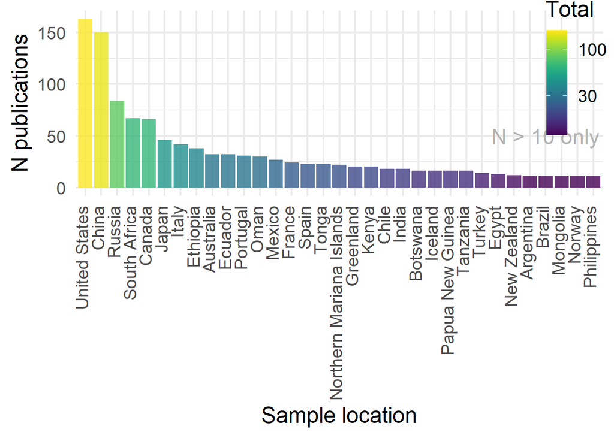

The largest number of publications concern samples from the United States and China (N>100) with Russia, South Africa and Canada (N>50) and Japan, Italy, Ethiopia, Australia, Ecuador, Portugal and Oman all well represented (N>25).

Just from this graph, Ethiopia, Oman, Mexico, and Kenya jump out as being highly represented in the form of samples but (as we will see) little represented in the form of authorship and particularly first authorship. This might tend to suggest issues of “parachute science”.

This will explored in more detail below.

## Parachute index

Following the approach of Raja et al. (2021 preprint, available here: https://doi.org/10.31223/X5802N). We have calculated for each country **sampled** the “parachute index”. This is defined as the log of the ratio of publications including local researchers to those not including researchers.

Negative numbers tend to imply a greater degree of parachute science while positive numbers imply a higher degree of domestic research (i.e. research on samples from a given country by researchers in that country)

Plotting the parachute index by country of sample origin

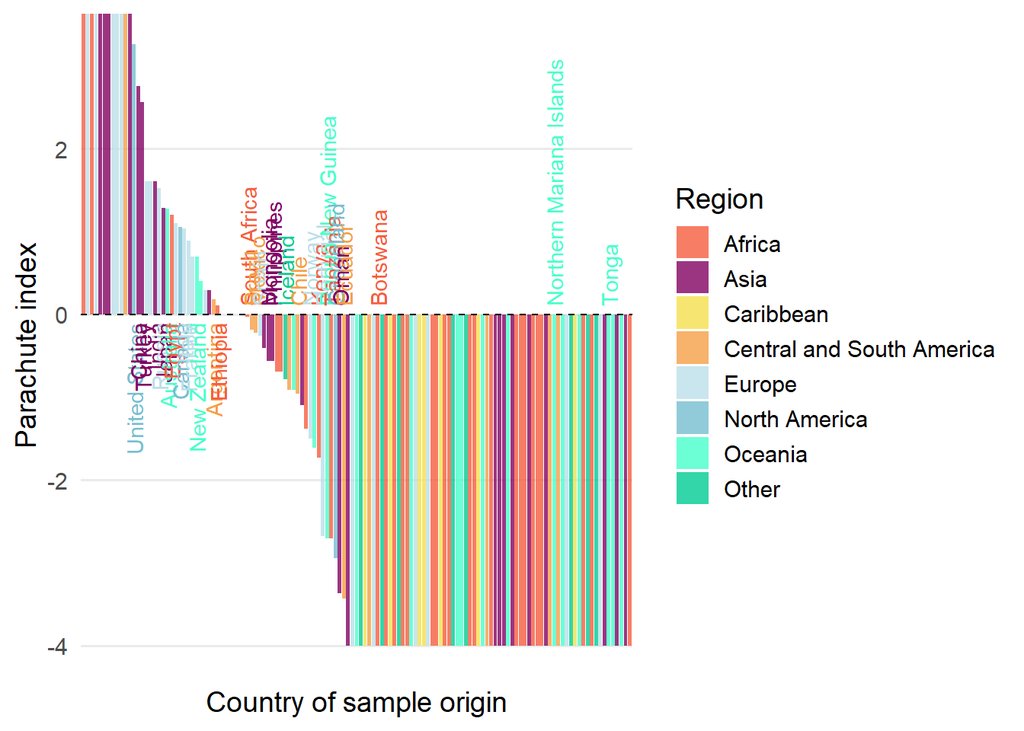

There are two main things clear from this plot. Firstly, notwithstanding a few countries with high positive indices but few total publications at the far left of the plot, the countries with positive indices (showing high rates of local involvement) are dominated by those from Europe, North America and Asia (pale blues and purple) as well as New Zealand and Australia. At the other end of the spectrum on the right hand side of the graph, countries with negative parachute indices (showing high levels of parachute science with no local involvement) tend to be in Africa, Central and South America, the Caribbean and Oceania.

It is particlarly notable just how many countries do not have a single publication with a local co-author. In several cases, including Botswana, Tonga and the N Marianas Islands this is despite 10 or more references in the database concering those countries.

## Stats by region

Since there are quite a few countries with a small overall number of publications, these tendencies are perhaps more clearly shown by summarising the parachute index data by regions and plotting the results.

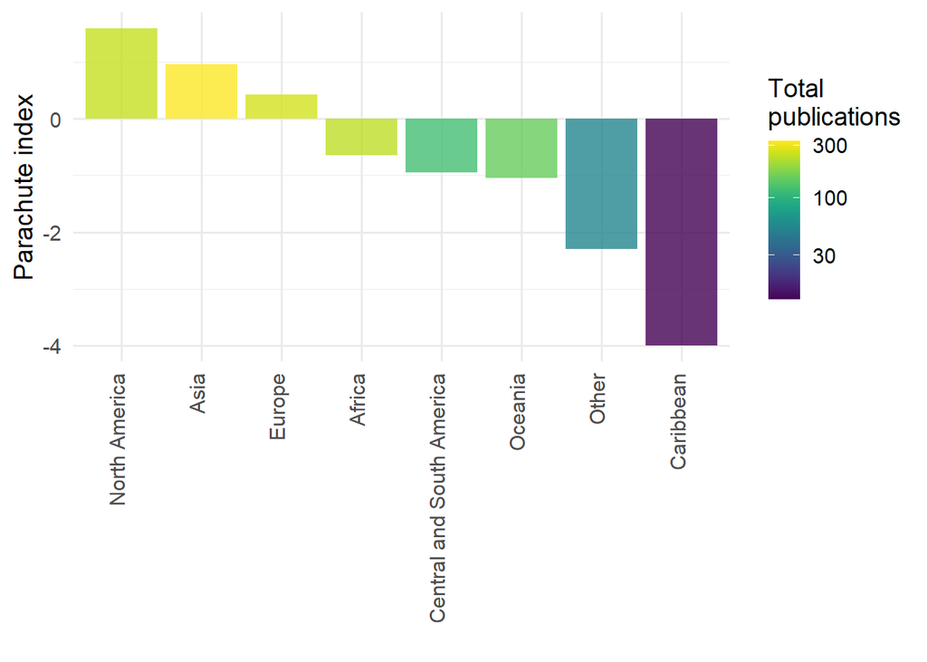

## Which countries do the most research in other countries?

It’s also useful to look at the country of the first author. Where are the places doing the most parachute science? (rather than subject to it as the above graphs illustrate)

First we recalculate similar summary statistics to those above for samples’ country and region of origin. This time we use the affiliation of the 1st author of each publication as the variable to summarise on.

Instead of parachute index we calculate simply the proportion of foreign research conducted (relative to the total number of publications from that country) and the proportion of that foreign research in which there was at least 1 local collaborator included as an author.

First we plot a bar chart showing the total publications from each country categorised as domestic, foreign and foreign with local involvement:

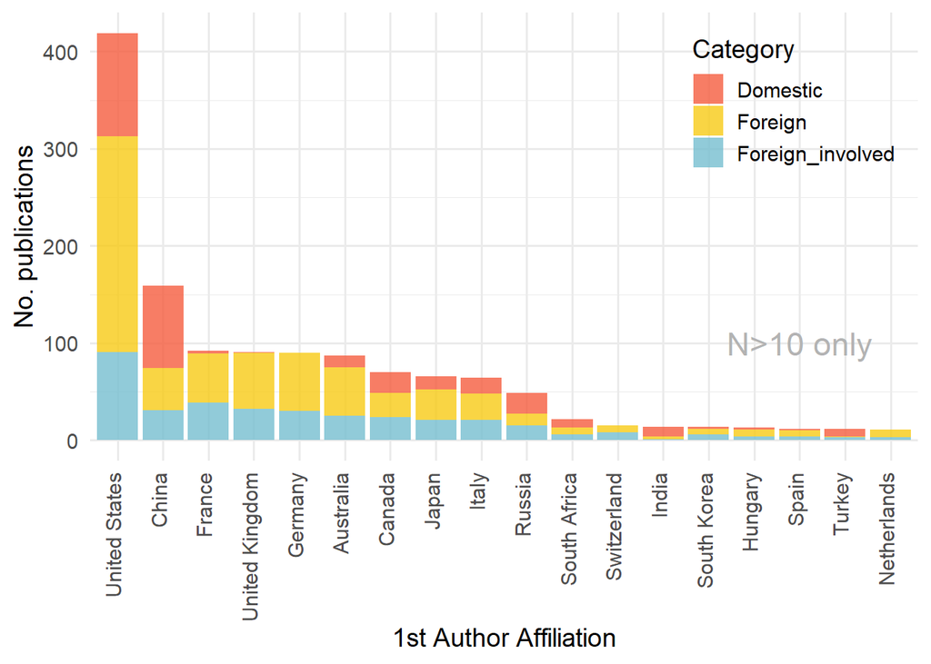

Is is clear from this chart that foreign research makes up a significant proportion of the publications for most of the countries with the largest numbers of publications (>50 publications). In particular, we can see that domestic research makes up a tiny proportion of the total output from the UK, France and Germany but that these countries have a large number of 1st authored papers, second only to the USA and China.

The USA and China have a somewhat larger proportion of domestic research and are the best represented in the dataset in terms of nubmer of first authored publications.

To look in more detail at the breakdown of research conducted abroad versus domestically we can plot the proportion of foreign research calculated above by country

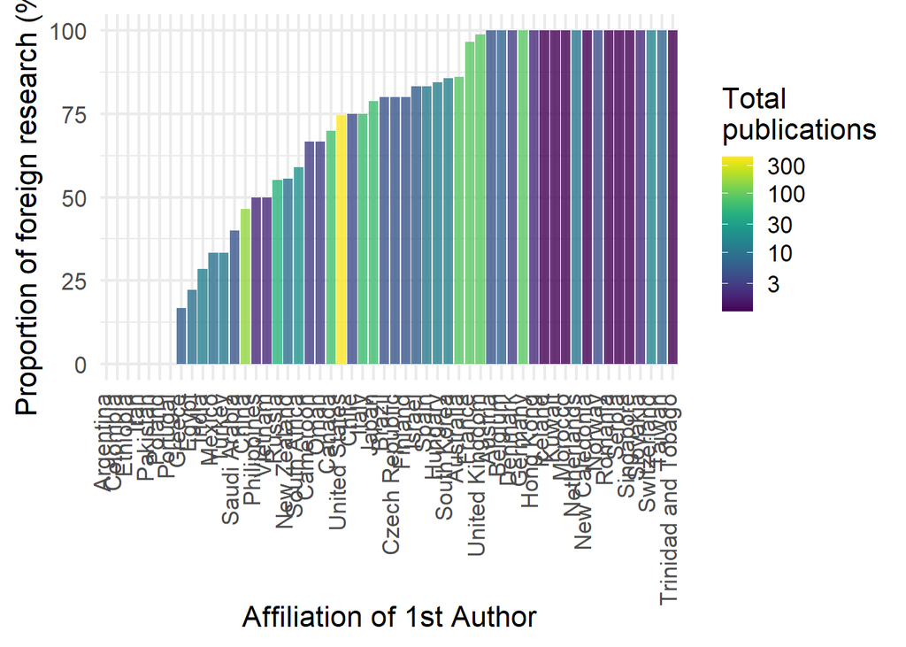

This plot reiterates several of the same features as the previous one. A large proportion of the published outputs from many European countries - including the UK, France and Germany - conduct a large proportion (>75% in most cases) of research abroad.

At the other end of the scale, on the left of the graph, countries with a large proportion of research conducted domestically are more typically in Africa, Asia or South America though Greece and Portugal also feature at this end of the graph.

A number of countries at the right of the graph show 100% of foreign research. Many of these however are represented by only a handful of publications (purple colours) and may not be particularly representative.

Lastly we can look at the proportion of foreign research which includes local collaborators:

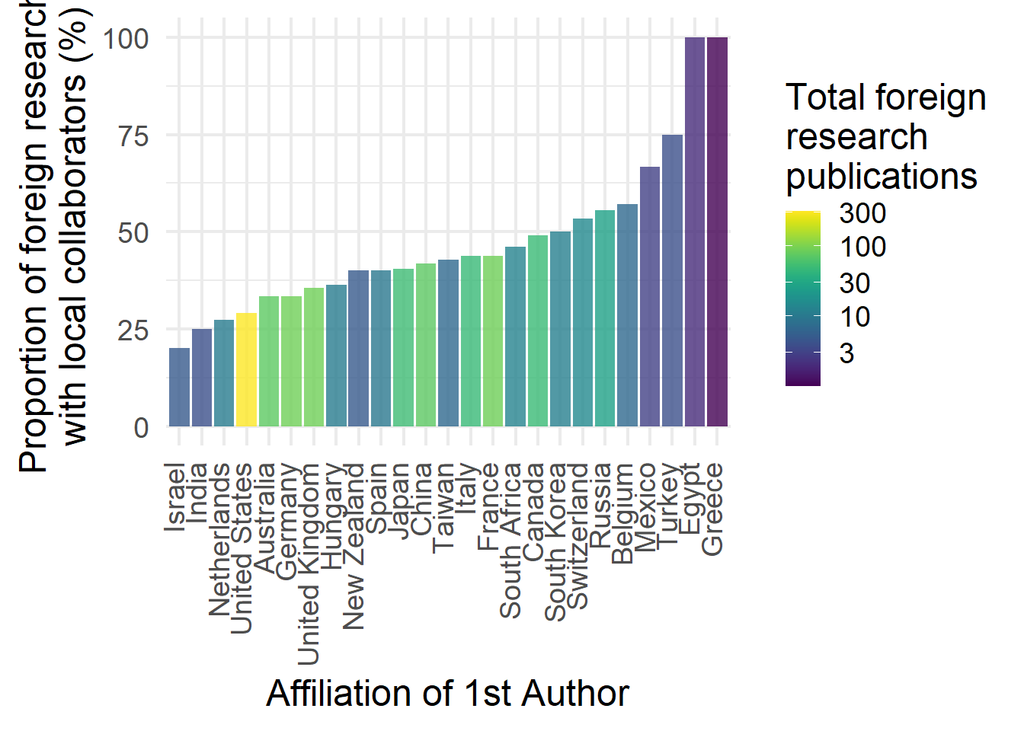

A number of countries with 100% local collaboration have low number of total foreign research publication (purple colours) as in the previous plot and may not be representative.